# ANOVA

Edward A. Roualdes

# Recap

## recap: point estimates

Point estimates are random variables. Random variables follow shapes, called distributions. Therefore, point estimates follow distributions (and have shapes).

## recap: central limit theorem

The Central Limit Theorem says, “If our sample size is large enough, the sample mean will be approximately Normally distributed.”

## recap: confidence intervals

From the CLT, we can approximate confidence intervals

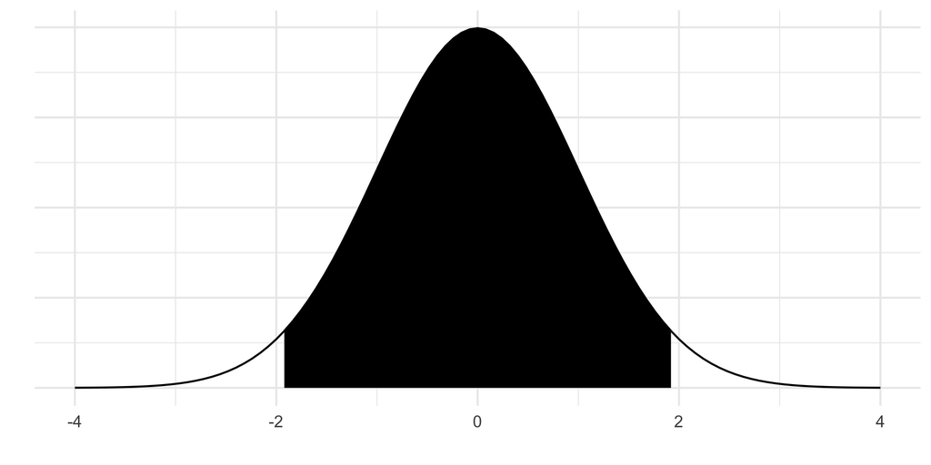

## recap: hypothesis tests

From the CLT, we can approximate area in tails (p-values)

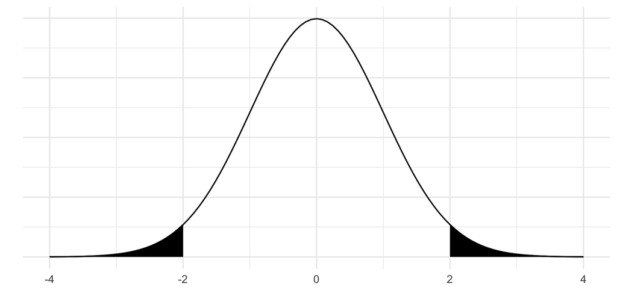

## recap: two sample t-tests

The two sample $t$-test, compares the means of two groups with the hypothesis

$$\begin{align*}
H_0: \quad & \mu_1 = \mu_2 \\
H_A: \quad & \mu_1 \ne \mu_2. \\
\end{align*}$$

R’s function `t.test()` did all the hard work for us.

# Analysis of Variance

## Analaysis of Variance

If there were three or more groups, the two sample $t$-test would not work. We could force the test on the data by comparing two groups at a time, but this has dangerous implications. We thus require a new statistical method, **analysis of variance**.

- **Analysis of variance (ANOVA)** uses a single hypothesis to check whether the *means* across two or more groups are equal.

## ANOVA, hypothesis

The ANOVA hypothesis test for $k$ groups is

$$\begin{align*}
H_0: \quad & \mu_1 = \mu_2 = \mu_3 = \ldots = \mu_k \\
H_A: \quad & \text{at least one mean is different.}
\end{align*}$$

**Note**

ANOVA tests equality of means across groups, despite its name.

## ANOVA, hypothesis examples

With ANOVA you can compare the means by groups for many different data sets.

- mean batting average by position,
- mean movie budget by genre, (or year),
- mean CO2 intake by treatment, or location, (or concentration)
- mean rem sleep by conservation status,
- mean birth/body weight by family,
- …

## ANOVA, picture

Let’s visualize what is going on with ANOVA. It starts with box plots by groups – draw more pictures on board.

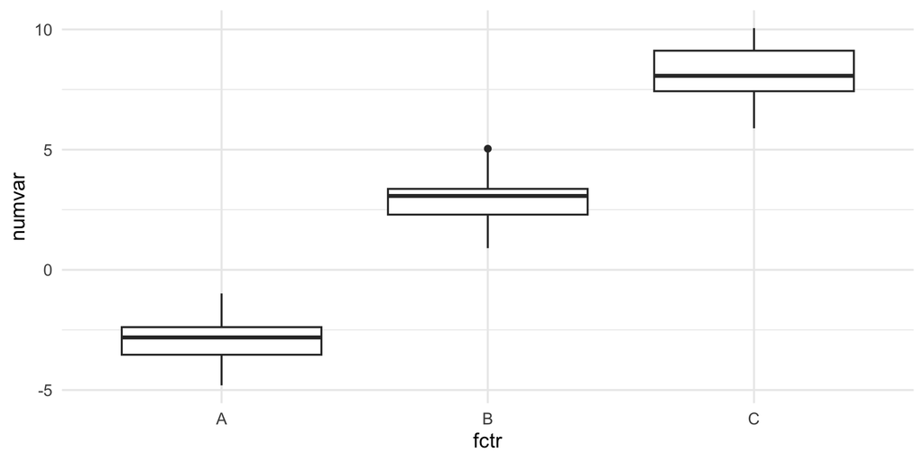

## ANOVA, intuition

Analysis of variance tells us about means by groups, despite its name. Large variation amongst the groups relative to small variation within the groups indicates different population means.

## ANOVA, intuition in picture

What do you think of these means – think of variation within and amongst groups?

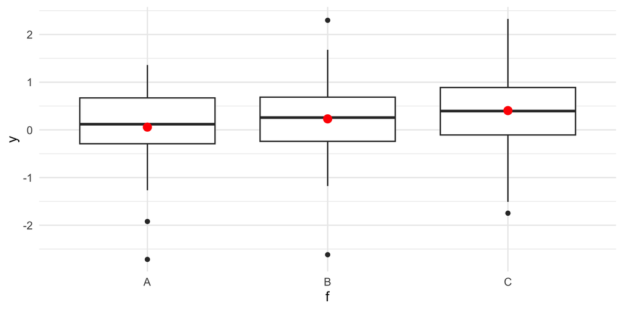

## ANOVA, intution via picture

What do you think of these means – think of variation within and amongst groups?

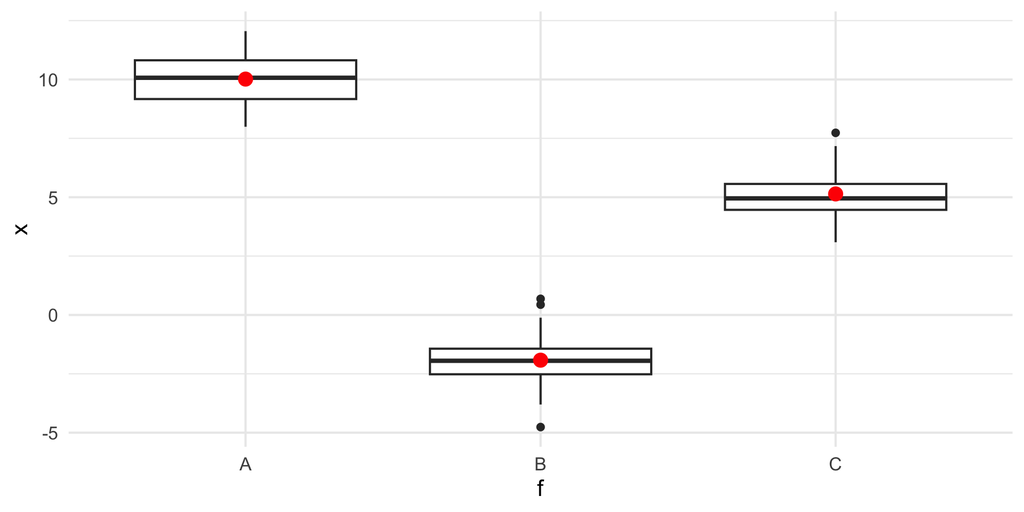

## ANOVA, test statistic

ANOVA calculates one fraction based on two numbers, variation amongst (between) groups and variation within groups. These two numbers are generally referred to as mean square values.

- mean squared amongst groups
  - **MSG** is a strictly positive measure of the variation across all groups.
- mean squared error/residuals
  - **MSE** is a strictly positive measure of the variation within groups.
- Test statistic
  - $F = \frac{MSG}{MSE}$

# First Example

## Baseball example, hypotheses

Are baseball players paid on average differently by position?

$$\begin{align*}
H_0: \quad & \mu_{catcher} = \mu_{dh} = \mu_{first} = \ldots = \mu_{third} \\
H_A: \quad & \text{at least one mean salary is different.}
\end{align*}$$

with $\alpha = 0.05$.

## Baseball example, plot

Load the data and make a plot.

```r
url <- "https://raw.githubusercontent.com/roualdes/data/master/mlb.csv"
mlb <- read.csv(url)
suppressMessages(library(tidyverse))
ggplot(data = mlb, aes(position, salary)) +
    geom_boxplot() +
    theme(axis.text.x = element_text(angle = 45, hjust=1))
```

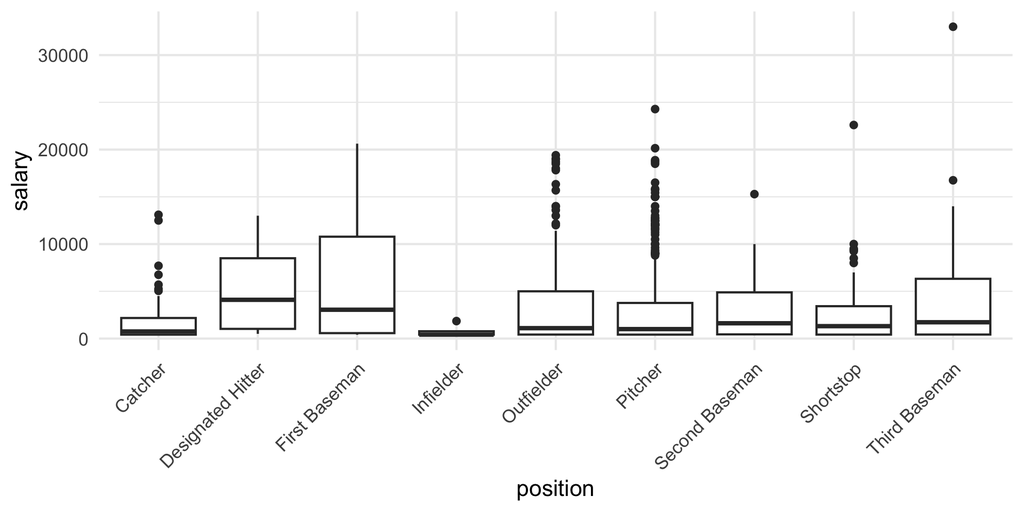

## Baseball example, R code

The R code to run ANOVA

```r
linear_model <- lm(salary ~ position, data = mlb)
anova(linear_model)
```

## Baseball example, R code details

The tilde $\sim$ is meant to be read as, predict the left hand side with the right hand side. Hence, we read the following as, predict salary by different levels of position.

```r
linear_model <- lm(salary ~ position, data = mlb)
```

## Baseball example, R output

The degrees of freedom, F-statistic, and p-value are the most important pieces of information to extract from an ANOVA table.

```r
anova(linear_model)
```

```
Analysis of Variance Table

Response: salary
           Df     Sum Sq  Mean Sq F value    Pr(>F)
position    8 6.0975e+08 76219146  3.9307 0.0001422 ***
Residuals 819 1.5881e+10 19390502
---
Signif. codes:  0 '***' 0.001 '**' 0.01 '*' 0.05 '.' 0.1 ' ' 1
```

## Baseball example, conclusion

Because the p-value $= 10^{-4} < \alpha = 0.05$ we reject the null in favor of the alternative. There is sufficient evidence to claim that the population of mean salaray of baseball players probably varies by position.

# Multiple Comparisons

## Multiple Comparisons, the problem

Say you’ve got some data and you want to test equality of the means. What to do? ANOVA!

```r
ggplot(data = mlb, aes(position, salary)) +
    geom_boxplot() +
    theme(axis.text.x = element_text(angle = 45, hjust=1))
```

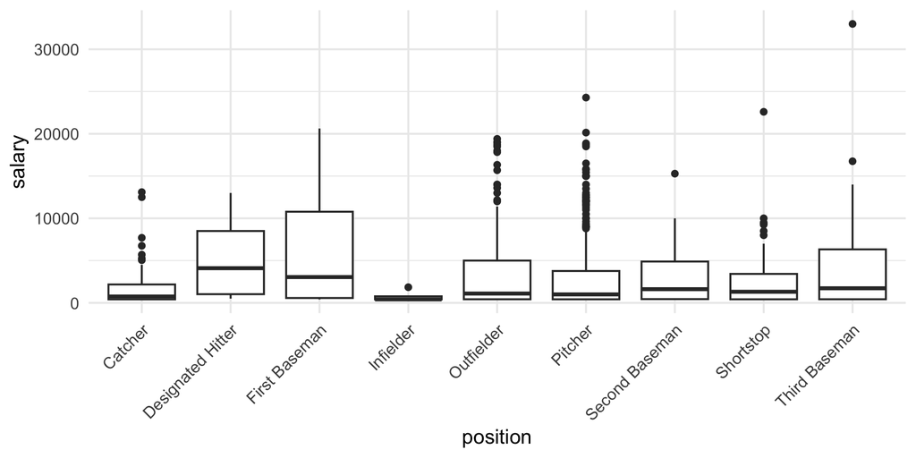

## Multiple Comparisons, the problem

What not to do? Immediately compare all pairwise combinations of the $k = 9$ groups. That would result in 36 tests, and an increase in your Type I Error rate.

## Multiple Comparisons, how bad a problem

Suppose you chose a level of significance of $\alpha = 0.05$. What’s the probability of observing at least one significant result just by chance?

This is just a binomial distribution, $X \sim$ Binomial$(36, 0.05)$, and we want to know $P(X \ge 1)$.

```
[1] 0.8422208
```

## Multiple Comparisons, a solution

Many solutions exist. A simple one, in R, is Tukey’s honest significant difference (HSD). Only use this if you have first run ANOVA and rejected $H_0$.

```r
model <- lm(salary ~ position, data = mlb) # if reject H0
TukeyHSD(aov(model)) # do in R
```

# Last Example

## Carnivora Brain Weights by Family, plot

Consider brain weights of the Families of the order Carnivora. Let’s compare mean brain weights by Family.

```r
suppressMessages({library(tidyverse)
  library(ape)
  data(carnivora)})
ggplot(data = carnivora, aes(Family, SB)) +
    geom_boxplot() +
    labs(y="Brain weights (g)") +
    theme(axis.text.x=element_text(angle=45, hjust=1))
```

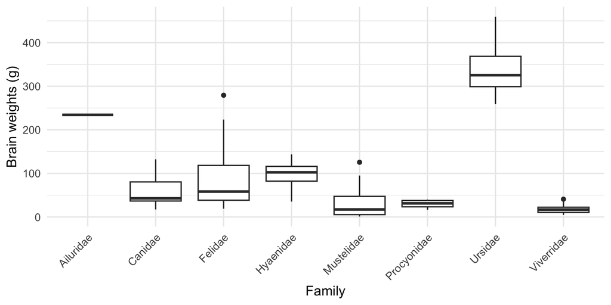

## Carnivora Brain Weights by Family, not all groups

Since some groups don’t have enough data, let’s remove them.

```r
carnivs <- filter(carnivora,
                  !(Family %in% c("Ailuridae",
                                  "Procyonidae",
                                  "Viverridae")))
```

## Carnivora Brain Weights by Family, hypotheses

$$\begin{align*}
H_0: \quad & \mu_c = \mu_f = \mu_h = \mu_m = \mu_u \\
H_A: \quad & \text{at least one mean is different.}
\end{align*}$$

with $\alpha = 0.01$.

## Carnivora Brain Weights by Family, R code

```r
mod <- lm(SB ~ Family, data = carnivs)
anova(mod)
```

```
Analysis of Variance Table

Response: SB
          Df Sum Sq Mean Sq F value    Pr(>F)
Family     4 354999   88750  37.333 < 2.2e-16 ***
Residuals 70 166406    2377
---
Signif. codes:  0 '***' 0.001 '**' 0.01 '*' 0.05 '.' 0.1 ' ' 1
```

## Carnivora Brain Weights by Family, conclusion

Because the p-value is tiny, we reject $H_0$ in favor of the alternative. There is sufficient evidence to say that at least one mean is different from the rest.

## Carnivora Brain Weights by Family, post-hoc analysis

```r
TukeyHSD(aov(mod), conf.level = 0.99) # do in R
```

## Take Away

- ANOVA breaks up the response variable into groups, chosen by you.
- ANOVA essentially calculates group means
  - average error within groups and average error amongst the groups.
- Understand the general ANOVA table
- Conclusions from ANOVA tables are easy
  - compare p-value to level of significance
- Interpretation of such conclusions is trickier, practice